# Etapa I

## Modelo matemático

Para identificar los determinantes de la firma de tratados recurrimos a un sistema probit. En este marco nuestra unidad de estudio son los pares de paises $ij$. Este par se asociará en un régimen de control si (1) sus beneficios económicos potenciales, (2) su afinidad en intereses internacionales, (3) los temas de no-proliferación están en la palestra, (4) las características políticas internas, y (5) las sanciones morales son suficiente incentivo para que el par de países se asocie. Siendo $T^*_{ij,t}$ la variable latente que describe los incentivos a que el par de asocie. $T_{ij,t}=1.[T^*_{ij,t}]$ es una variable binaria que nos indica si los países están asociados en un régimen de control. Con esto de fondo estimamos los coeficientes de los determinantes de la variable latente.
$$T^*_{ij,t}=\beta_{ij}+X^{BB}_{ij,t}\beta+\gamma_1X^{pta}_{ij}+\gamma_2\sum_{z=0}^5Terr_{ij,t-z}+\gamma_3\left(\sum_{z=0}^5Terr_{ij,t-z}\right)^2+X_{ij,t}^{wg}\gamma_{4}+RégimenPolítico_{ij,t}$$

## Datos

Del Dynamic Gravity Dataset[^1] obtenemos las variables propias del modelo gravitacional.

```r
gdf0 <-read.csv("data/gravity/gds-1/release_2.1_1948_1959.csv")
gdf1 <-read.csv("data/gravity/gds-1/release_2.1_1960_1969.csv")
gdf2 <-read.csv("data/gravity/gds-1/release_2.1_1970_1979.csv")
gdf3 <-read.csv("data/gravity/gds-1/release_2.1_1980_1989.csv")
gdf4 <-read.csv("data/gravity/gds-1/release_2.1_1990_1999.csv")
gdf5 <-read.csv("data/gravity/gds2/release_2.1_2000_2004.csv")
gdf6 <-read.csv("data/gravity/gds2/release_2.1_2005_2009.csv")
gdf7 <-read.csv("data/gravity/gds2/release_2.1_2010_2014.csv")
gdf8 <-read.csv("data/gravity/gds2/release_2.1_2015_2019.csv")

gdf <- rbind(gdf0,gdf1,gdf2,gdf3,gdf4,gdf5,gdf6,gdf7,gdf8)

rm(gdf0,gdf1,gdf2,gdf3,gdf4,gdf5,gdf6,gdf7,gdf8)

save(gdf, file = "data/output/gravitydat.RData")
```

```r
load("data/output/gravitydat.RData")
```

Acá se nos presentan pares direccionados de países por año. Las variables que nos interesan son:

- rgdp: el producto interno bruto real.
- agree_pta: dummy de si los países tienen un acuerdo de libre comercio.
- contiguity: dummy de si los países comparten frontera.
- distance: distancia de gran circulo entre centros de los países, ponderados por concentración de la población.
- wto: dummy de si pertenece al GATT o al WTO.
- region: región del país.
- common_laguage: dummy de si los países comparten idioma.
- pop: población

Con estas variables podemos construir los beneficios económicos potenciales de un acuerdo. La base, igual que el comtrade, considera las zonas francas como una entidad, las retiramos. También retiramos a la Unión Europea, porque es el único bloque que se tiene en la base y es apropiado tratar a los países por separado. Finalmente, retiramos también Luxemburgo-Belga, que se considera una entidad sin asignarle un punto con el cual calcular su distancia con los países.

### Variables Baier Bergstrand (BB)

Estas son variables que resumen los beneficios económicos potenciales del comercio libre entre dos países, estas son variables que afectan la probabilidad de concertar un acuerdo. Entonces, si consideramos que la base tiene $n_t$ países en el año $t$, y $N_t=\frac{(n_t-1)n_t}{2}$ pares de países. El par $ij$ está compuesto del país $i$ y el país $j$. Los beneficios económicos son bilaterales, pues nos interesan sólo en la medida en que incrementen la probabilidad de una firma, y para ello estos beneficios tienen que recoger los incentivos desde ambos lados. Baier y Bergtrand (2004)[^2] las enuncian y Egger y Larch (2008)[^3] generan los proxies que usamos. BB 2004 dicen que los países tienen más incentivos a comerciar cuando:

- tienen bajos costos de transacción.
  1. natural: $- log(distance_{ij,t})$
  2. dregion: Dummy si comparten región.
  3. rgdpsum: $log(rgdp_{it}+rgdp_{jt})$
- tienen tamaños comparables.
  1. rgdpsim: $log\left(1-\frac{rgdp_{it}^2}{(rgdp_{it}+rgdp_{jt})^2}-\frac{rgdp_{jt}^2}{(rgdp_{it}+rgdp_{jt})^2}\right)$
- tienen diferentes dotaciones de factores.
  1. dkl: $\left|log\left(\frac{rgdp_{it}}{pop_{it}}\right)-log\left(\frac{rgdp_{jt}}{pop_{jt}}\right)\right|$
- tienen altos costos de transacción con el resto del mundo.
  1. remote: $\frac{1}{2}\left[\frac{\sum_{l\neq i}distance_{il,t}}{N_t-1}+\frac{\sum_{l\neq j}distance_{jl,t}}{N_t-1}\right]$
- tienen dotaciones de factores similares al resto del mundo.
  1. dotext: $\frac{1}{2}\sum_{k\in\{i,j\}}\left|log\left(\frac{\sum_{l\neq k}rgdp_{lt}}{\sum_{l\neq i}pop_{lt}}\right)-log\left(\frac{rgdp_{kt}}{pop_{kt}}\right)\right|$

```r
eggerdf <- gdf %>%
  filter(!(iso3_o == iso3_d) &
         !(iso3_o %in% c("EUN","FRE","BLX"))&
         !(iso3_d %in% c("EUN","FRE","BLX"))) %>%
  group_by(year, iso3_o) %>%
  mutate(remote_o = sum(distance,na.rm=T)/n()) %>%
  ungroup() %>% group_by(year, iso3_d) %>%
  mutate(remote_d = sum(distance,na.rm=T)/n()) %>% ungroup %>%
  mutate(remote = (remote_o + remote_d)/2) %>%
  select(-c("remote_o","remote_d")) %>%
  rename(rgdp_o = gdp_wdi_const_o,
         rgdp_d = gdp_wdi_const_d) %>%
  group_by(year,iso3_o) %>%
  mutate(dotext_o = abs(log(sum(rgdp_d,na.rm=T)/sum(pop_d,na.rm=T))-log(rgdp_o/pop_o))) %>%
  ungroup() %>% group_by(year,iso3_d) %>%
  mutate(dotext_d = abs(log(sum(rgdp_o,na.rm=T)/sum(pop_o,na.rm=T))-log(rgdp_d/pop_d))) %>%
  ungroup() %>%
  mutate(dotext = (dotext_o+dotext_d)/2) %>%
  select(-c("dotext_o","dotext_d")) %>%
  mutate(natural = log((distance)^(-1)),
         rgdpsum = log(rgdp_o+rgdp_d),
         rgdpsim = log(1- rgdp_o^2/(rgdp_o+rgdp_d)^2 - rgdp_d^2/(rgdp_o+rgdp_d)^2),
         dkl = abs(log(rgdp_o/pop_o) - log(rgdp_d/pop_d)),
         wto_o = 1-(member_wto_o-1)*(member_gatt_o-1),
         wto_d = 1-(member_wto_d-1)*(member_gatt_d-1),
         wto = wto_o*wto_d,
         dregion = ifelse(region_d == region_o,1,0)) %>%
  select(year,country_o,iso3_o,country_d,iso3_d,agree_pta,contiguity,distance,wto,
         region_o,region_d,common_language,rgdp_o,rgdp_d, pop_o, pop_d,
         remote,dregion,natural,rgdpsum,rgdpsim,dkl,dotext)
```

```r
plotdf <- eggerdf %>%
  group_by(year, iso3_o) %>%
  mutate(pareos = n(),
         pardis = sum(!is.na(distance))) %>% ungroup() %>%
  group_by(year) %>%
  mutate(max_pareos = max(pareos,na.rm =T ))  %>% ungroup() %>%
  mutate(pareo_ratio = pareos/max_pareos,
         p_rgdp = ifelse(!is.na(rgdp_o),1,0),
         p_pop  = ifelse(!is.na(pop_o) ,1,0),
         distan_ratio = pardis/pareos) %>%
  select(year,country_o,iso3_o,p_rgdp,p_pop,pareo_ratio,distan_ratio) %>%
  unique() %>%
  group_by(year,iso3_o) %>%
  filter(p_rgdp == max(p_rgdp, na.rm=T)) %>% ungroup() %>%
  group_by(iso3_o) %>%
  mutate(presence = n(),
         last_year = ifelse(year == max(year), 1,0)) %>% ungroup()
plotdf <- plotdf %>% merge(rename(select(filter(plotdf,last_year == 1),country_o,iso3_o),country_p = country_o))
```

```r
aux <- eggerdf %>% select(year,iso3_o,rgdp_o) %>%
  rbind(rename(select(eggerdf,year,iso3_d,rgdp_d),
               iso3_o = iso3_d,
               rgdp_o = rgdp_d)) %>%
  unique() %>% rename(rgdp = rgdp_o) %>%
  group_by(year,iso3_o) %>%
  mutate(rgdp_o = mean(rgdp,na.rm=T)) %>% select(-rgdp) %>%
  unique()

eggerdf <- eggerdf %>% mutate(pair = case_when(iso3_o > iso3_d ~ paste(iso3_o,iso3_d),
                              .default = paste(iso3_d,iso3_o)))
eggerdf <- eggerdf[!duplicated(eggerdf[,c('year','pair')]),]



eggerdf <- eggerdf %>%
  select(-c("rgdp_d","rgdp_o")) %>%
  merge(aux) %>%
  merge(rename(aux,iso3_d = iso3_o, rgdp_d = rgdp_o))
rm(aux)
```

Hagamos unos resultados preliminares para contrastar la base que aquí creamos con la de Egger Y Larch (2008).

```r
bbmodel <- glm(agree_pta ~ natural + rgdpsum + rgdpsim + dkl + dkl2 + dregion + remote + dotext, family = binomial(link = "probit"), data = mutate(eggerdf,dkl2 = dkl^2))

summary(bbmodel)
```

```
##
## Call:
## glm(formula = agree_pta ~ natural + rgdpsum + rgdpsim + dkl +
##     dkl2 + dregion + remote + dotext, family = binomial(link = "probit"),
##     data = mutate(eggerdf, dkl2 = dkl^2))
##
## Coefficients:
##               Estimate Std. Error z value Pr(>|z|)
## (Intercept) -1.185e+00  4.818e-02 -24.586   <2e-16 ***
## natural      3.843e-01  3.620e-03 106.148   <2e-16 ***
## rgdpsum      1.329e-01  1.381e-03  96.304   <2e-16 ***
## rgdpsim      9.137e-02  1.681e-03  54.357   <2e-16 ***
## dkl          1.192e-02  5.920e-03   2.013   0.0441 *
## dkl2        -2.389e-02  1.425e-03 -16.760   <2e-16 ***
## dregion      7.831e-01  6.722e-03 116.506   <2e-16 ***
## remote       3.478e-05  2.391e-06  14.543   <2e-16 ***
## dotext      -4.755e-05  3.934e-03  -0.012   0.9904
## ---
## Signif. codes:  0 '***' 0.001 '**' 0.01 '*' 0.05 '.' 0.1 ' ' 1
##
## (Dispersion parameter for binomial family taken to be 1)
##
##     Null deviance: 527647  on 557217  degrees of freedom
## Residual deviance: 437054  on 557209  degrees of freedom
##   (1065567 observations deleted due to missingness)
## AIC: 437072
##
## Number of Fisher Scoring iterations: 5
```

Estos resultados se aproximan en su mayoría a lo obtenido por Egger Y Larch (2008)

### Tratados de no-proliferación

Ahora generamos las variables sobre los régimenes de control y los tratados que son relevantes en este estudio. Generalmente consideramos le fecha de depósito inicial (ratificación o aceptación), no la firma, esto porque viendo los datos vi más variación por este lado. Por ahora estamos estudiando la participación en los tratados:

- Acuerdo de Wassenaar.
- Convención de armas químicas.
- Convención de armas biológicas.
- Tratado de no-proliferación nuclear.
- Grupo Australia.
- Régimen de control de teconología de misiles.
- Grupo de proveedores nucleares.

```r
wamem <- data.frame(iso3= c("ARG", "AUS", "AUT", "BEL", "BGR", "CAN", "CZE", "DNK",
                                    "EST", "FIN", "FRA", "DEU", "GRC", "HRV", "HUN", "IND",
                                    "IRL", "ITA", "JPN", "LTU", "LUX", "LVA", "MEX", "MLT",
                                    "NLD", "NZL", "NOR", "POL", "PRT", "KOR", "ROU", "RUS",
                                    "SVK", "SVN", "ESP", "SWE", "CHE", "TUR", "UKR", "GBR",
                                    "USA", "ZAF")) %>%
  mutate(since = case_when(iso3 %in% c("CZE", "HUN", "POL", "RUS", "SVK") ~ 1995,
                           iso3 %in% c("ARG", "BGR", "KOR", "ROU", "UKR") ~ 1996,
                           iso3 %in% c("SVN") ~ 2004,
                           iso3 %in% c("EST", "HRV", "LTU", "LVA", "MLT", "ZAF") ~ 2005,
                           iso3 %in% c("MEX") ~ 2012,
                           iso3 %in% c("IND") ~ 2017,
                          .default = 1994))
```

```r
cwc <- read.delim("data/cwc-signings.csv",sep=",") %>%
  mutate(iso3 = countrycode::countrycode(party,"country.name","iso3c"),
         since=str_sub(entered.into.force,-4,-1))
cwc[cwc$entered.into.force=="12-Oct-1997",]$iso3 <- "GUY"
cwc[cwc$entered.into.force=="21-Jul-1999",]$iso3 <- "FSM"
```

```r
bwc <- read.delim("data/Bwc-signings.csv",sep=",") %>%
  mutate(iso3 = countrycode::countrycode(State,"country.name","iso3c"),
         since=substr(Deposited,9,12))
bwc[bwc$Deposited=="Mar 26, 2013(W)",]$iso3 <- "GUY"
bwc[bwc$Deposited=="Jul 12, 2024(W)",]$iso3 <- "FSM"
```

```r
npt <- read.delim("data/npt-signings.csv",sep=",") %>%
  mutate(iso3 = countrycode::countrycode(State,"country.name","iso3c"),
         since=str_sub(Deposited,-5,-2))
npt[is.na(npt$iso3),]$iso3 <- "GUY"
```

```r
agr <- read.delim("data/ag-signings.csv",sep=",") %>%
  filter(Country != "European Union") %>%
  mutate(iso3 = countrycode::countrycode(Country,"country.name","iso3c")) %>%
  rename(since = Date)
```

```r
mtcr <- read.delim("data/mtcr-signings.csv",sep=",") %>%
  mutate(iso3 = countrycode::countrycode(country,"country.name","iso3c"))
```

```r
nsg <- read.delim("data/nsg-signings.csv",sep=",") %>%
  mutate(iso3 = countrycode::countrycode(country,"country.name","iso3c"))
```

```r
dfs1 <- eggerdf %>%
  merge(rename(wamem,iso3_o=iso3),all.x = T) %>%
  mutate(wass_o = ifelse(year<since,0,1)) %>%
  merge(rename(wamem,iso3_d=iso3),all.x = T) %>%
  mutate(wass_d = ifelse(year<since,0,1),
         wass = wass_o*wass_d) %>%
  select(-c("wass_o","wass_d","since")) %>%
  merge(rename(select(cwc,iso3,since),iso3_o=iso3),all.x = T) %>%
  mutate(cwc_o = ifelse(year<since,0,1)) %>%
  merge(rename(select(cwc,iso3,since),iso3_d=iso3),all.x = T) %>%
  mutate(cwc_d = ifelse(year<since,0,1),
         cwc = cwc_o*cwc_d) %>%
  select(-c("cwc_o","cwc_d","since")) %>%
  merge(rename(select(bwc,iso3,since),iso3_o=iso3),all.x = T) %>%
  mutate(bwc_o = ifelse(year<since,0,1)) %>%
  merge(rename(select(bwc,iso3,since),iso3_d=iso3),all.x = T) %>%
  mutate(bwc_d = ifelse(year<since,0,1),
         bwc = bwc_o*bwc_d) %>%
  select(-c("bwc_o","bwc_d","since")) %>%
  merge(rename(select(npt,iso3,since),iso3_o=iso3),all.x = T) %>%
  mutate(npt_o = ifelse(year<since,0,1)) %>%
  merge(rename(select(npt,iso3,since),iso3_d=iso3),all.x = T) %>%
  mutate(npt_d = ifelse(year<since,0,1),
         npt = npt_o*npt_d) %>%
  select(-c("npt_o","npt_d","since")) %>%
  merge(rename(select(agr,iso3,since),iso3_o=iso3),all.x = T) %>%
  mutate(agr_o = ifelse(year<since,0,1)) %>%
  merge(rename(select(agr,iso3,since),iso3_d=iso3),all.x = T) %>%
  mutate(agr_d = ifelse(year<since,0,1),
         agr = agr_o*agr_d) %>%
  select(-c("agr_o","agr_d","since")) %>%
  merge(rename(select(mtcr,iso3,since),iso3_o=iso3),all.x = T) %>%
  mutate(mtcr_o = ifelse(year<since,0,1)) %>%
  merge(rename(select(mtcr,iso3,since),iso3_d=iso3),all.x = T) %>%
  mutate(mtcr_d = ifelse(year<since,0,1),
         mtcr = mtcr_o*mtcr_d) %>%
  select(-c("mtcr_o","mtcr_d","since")) %>%
  merge(rename(select(nsg,iso3,since),iso3_o=iso3),all.x = T) %>%
  mutate(nsg_o = ifelse(year<since,0,1)) %>%
  merge(rename(select(nsg,iso3,since),iso3_d=iso3),all.x = T) %>%
  mutate(nsg_d = ifelse(year<since,0,1),
         nsg = nsg_o*nsg_d) %>%
  select(-c("nsg_o","nsg_d","since"))

dfs1[is.na(dfs1$wass),]$wass <- 0
dfs1[is.na(dfs1$cwc),]$cwc <- 0
dfs1[is.na(dfs1$bwc),]$bwc <- 0
dfs1[is.na(dfs1$npt),]$npt <- 0
dfs1[is.na(dfs1$agr),]$agr <- 0
dfs1[is.na(dfs1$mtcr),]$mtcr <- 0
dfs1[is.na(dfs1$nsg),]$nsg <- 0

dfs1 <- dfs1 %>%
  mutate(cr = 1-(1-wass)*(1-cwc)*(1-bwc)*(1-npt)*(1-agr)*(1-mtcr)*(1-nsg))
```

```r
plotdf<- plotdf %>% merge(rename(wamem,iso3_o=iso3),all.x = T) %>%
  mutate(wass = year>=since) %>%
  select(-c("since")) %>%
  merge(rename(select(cwc,iso3,since),iso3_o=iso3),all.x = T) %>%
  mutate(cwc = year>=since,
         cr0 = (wass|cwc)&!is.na(wass|cwc)) %>%
  select(-c("wass","cwc","since")) %>%
  merge(rename(select(bwc,iso3,since),iso3_o=iso3),all.x = T) %>%
  mutate(bwc = year>=since,
         cr1 = (cr0|bwc)&!is.na(cr0|bwc)) %>%
  select(-c("bwc","cr0","since")) %>%
  merge(rename(select(npt,iso3,since),iso3_o=iso3),all.x = T) %>%
  mutate(npt = year>=since,
         cr2 = (cr1|npt)&!is.na(cr1|npt)) %>%
  select(-c("npt","cr1","since")) %>%
  merge(rename(select(agr,iso3,since),iso3_o=iso3),all.x = T) %>%
  mutate(agr = year>=since,
         cr3 = (cr2|agr)&!is.na(cr2|agr)) %>%
  select(-c("agr","cr2","since")) %>%
  merge(rename(select(mtcr,iso3,since),iso3_o=iso3),all.x = T) %>%
  mutate(mtcr = year>=since,
         cr4 = (cr3|mtcr)&!is.na(cr3|mtcr)) %>%
  select(-c("mtcr","cr3","since")) %>%
  merge(rename(select(nsg,iso3,since),iso3_o=iso3),all.x = T) %>%
  mutate(nsg = year>=since,
         cr = (cr4|nsg)&!is.na(cr4|nsg)) %>%
  select(-c("nsg","cr4","since"))
```

### Afinidad política

Para estudiar la aliniación que tienen los países con respecto a temas de política internacional, usamos el índice de afinidad en las votaciones de la ONU.

```r
load("data/AgreementScoresAll_Jun2024.RData")
dfAgree <- dfAgree %>% mutate(iso3_o = countrycode::countrycode(ccode1,"cown","iso3c"), iso3_d = countrycode::countrycode(ccode2,"cown","iso3c"))

dfAgree[dfAgree$ccode1 == 315,]$iso3_o <- "CZR"
dfAgree[dfAgree$ccode1 == 345,]$iso3_o <- "YUG"
dfAgree[dfAgree$ccode1 == 678,]$iso3_o <- "YEM"
dfAgree[dfAgree$ccode1 == 511,]$iso3_o <- "ZPM"
dfAgree[dfAgree$ccode1 == 680,]$iso3_o <- "YPR"
dfAgree[dfAgree$ccode1 == 260,]$iso3_o <- "DEU"
dfAgree[dfAgree$ccode1 == 265,]$iso3_o <- "DDR"
dfAgree[dfAgree$ccode2 == 315,]$iso3_d <- "CZR"
dfAgree[dfAgree$ccode2 == 345,]$iso3_d <- "YUG"
dfAgree[dfAgree$ccode2 == 678,]$iso3_d <- "YEM"
dfAgree[dfAgree$ccode2 == 511,]$iso3_d <- "ZPM"
dfAgree[dfAgree$ccode2 == 680,]$iso3_d <- "YPR"
dfAgree[dfAgree$ccode2 == 260,]$iso3_d <- "DEU"
dfAgree[dfAgree$ccode2 == 265,]$iso3_d <- "DDR"

dfs1 <- dfs1 %>%
  merge(select(ungroup(dfAgree),iso3_d,iso3_o,year,agree),all.x = T)
```

```r
aux <- dfAgree %>% ungroup() %>%
  mutate(id = paste(year,iso3_o))
plotdf <- plotdf %>%
  mutate(onu = paste(year,iso3_o) %in% aux$id)
rm(aux)
```

### Global terrorism database (GTD)

La GTD es del centro de estudios del terrorismo y respuestas al terrorismo de la Universidad de Maryland. Este mismo centro desarrolló en 2018 la base de datos de perfiles de incidentes de naturaleza química, biológica, radiológica y nuclear y actores no gubernamentales (POICN). Estos esfuerzos describen los incidentes que traen a colación internacional y nacional la discusión sobre la importancia de los regimenes de control, especialmente POINC, Binder Y Ackerman (2018)[^4]. El acceso a POICN se obtiene escribiendo a start-vnsa-cbrn-database@umd.edu. La GTD incluye datos desde 1960 hasta 2021.

```r
gtdf0 <- readxl::read_xlsx("data/globalterrorismdb_2021Jan-June_1222dist.xlsx")
gtdf <- readxl::read_xlsx("data/globalterrorismdb_0522dist.xlsx") %>%
  rbind(gtdf0) %>% filter(doubtterr == 0) %>%
  mutate(iso3 = countrycode::countrycode(country_txt,"country.name","iso3c"), list = paste(iyear,iso3))
rm(gtdf0)
```

```r
dfs1 <- dfs1 %>%
  mutate(terr = case_when(paste(year,iso3_o) %in% gtdf$list & paste(year,iso3_d) %in% gtdf$list ~ 1,
                          paste(year,iso3_o) %in% gtdf$list | paste(year,iso3_d) %in% gtdf$list ~ 0.5,
                          .default = 0)) %>%
  group_by(iso3_d,iso3_o) %>%
         mutate(terr0 = lag(terr, default = 0,order_by = year),
                terr1 = lag(terr,2, default = 0,order_by = year),
                terr2 = lag(terr,3, default = 0,order_by = year),
                terr3 = lag(terr,4, default = 0,order_by = year),
                terr4 = lag(terr,5, default = 0,order_by = year)) %>%
  ungroup() %>% group_by(year,iso3_d,iso3_o) %>%
  mutate(terr5 = max(terr,terr0,terr1,terr2,terr3,terr4),
         terr5.alt = sum(terr,terr0,terr1,terr2,terr3,terr4)) %>%
  select(-c("terr0","terr1","terr2","terr3","terr4")) %>% ungroup()
```

```r
plotdf <- plotdf %>% mutate(terr = ifelse(paste(year,iso3_o) %in% gtdf$list,1,0))
```

Cuando la GTD registra un ataque terrorista sin ambigüedad en el país $i$, durante el año $t$, $terr_{it} = 1$. Así Construimos la variable $terr_{ij,t}=\frac{1}{2}[terr_{it}+terr_{jt}]$. También nos interesa ver la persistencia de estos ataques en las presiones políticas, de modo que generamos dos variables.

- terr5: $\max_{z\in\{0,1,2,3,4,5\}}\{terr_{ij,t-z}\}$. Que observa la presencia de un ataque terrorista cercano en cada país.
- terr5.alt: $\sum_{z=0}^5terr_{ij,t-z}$ Que acumula los ataques terroristas cercanos, esta variable nos ayuda a ver la heterogeneidad entre países donde el terrorismo es permanente y países donde el terrorismo es una excepción relevante en el ámbito político.

### Who Govs

Así como previamente tomamos los promedios de una variable escencialmente unilateral (un ataque terrorista en el territorio), haremos lo mismo con la serie de variables de ciencia política que nos son relevantes. La base de datos whogov tiene observaciones desde 1966 hasta 2023, Nyrup Y Bramwell (2020)[^5]. Estas son:

- n_party : Cantidad de partidos representados en el govierno.
- n_militarytitle_minister: Cantidad de ministros con títulos militares.
- system_category: tipo de régimen categorizado por Cheibub et al. (2010)[^6].

Me encantaría tener datos de aliniamiento en el espectro izquierda-derecha.

```r
whogov <- read.delim("data/WhoGov_crosssectional_V3.0.csv",sep=",")

aux <- whogov %>% rename(iso3_o = country_isocode,
                         n_party_o = n_party,
                         system_category_o = system_category) %>%
  mutate(n_military_o = n_militarytitle_minister/n_minister)%>%
  select(year, iso3_o, n_party_o, n_military_o, system_category_o)

dfs1 <- dfs1 %>% merge(aux,all.x = T)
rm(aux)

aux <- whogov %>% rename(iso3_d = country_isocode,
                         n_party_d = n_party,
                         system_category_d = system_category) %>%
  mutate(n_military_d = n_militarytitle_minister/n_minister) %>%
  select(year, iso3_d, n_party_d, n_military_d, system_category_d)

dfs1 <- dfs1 %>% merge(aux,all.x = T) %>%
  mutate(n_party = (n_party_o+n_party_d)/2,
         n_military = (n_military_o+n_military_d)/2,
         system_category =ifelse(system_category_o>system_category_d,
                                  paste(system_category_o,system_category_d),
                                  paste(system_category_d,system_category_o)))
rm(aux)
```

```r
aux <- whogov %>%
  mutate(id = paste(year,country_isocode))
plotdf <- plotdf %>%
  mutate(whogov = paste(year,iso3_o) %in% aux$id)
aux <- whogov %>%
  select(year,country_isocode,n_party) %>%
  rename(iso3_o = country_isocode) %>%
  mutate(na_party = is.na(n_party)) %>%
  select(-n_party)
plotdf <- plotdf %>%
  merge(aux,all.x = T)
rm(aux)
plotdf[is.na(plotdf$na_party),]$na_party <- TRUE
```

### Presencia de datos en la base

Me parece importante mostrarte la distribución de datos que tenemos entre los países. Hay países para los que tenemos la afinidad política, pero donde quizá no tenemos el PIB real. Bajo esto, veremos la presencia de datos de cada país a lo largo del periodo que abarca la base.

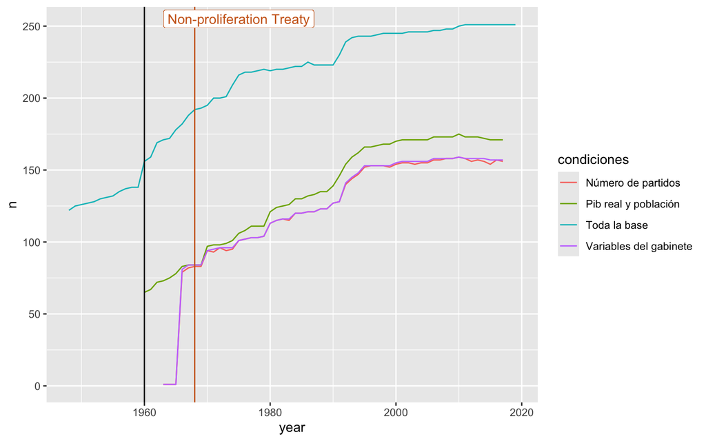

```r
aux0 <- plotdf %>% group_by(year) %>% mutate(n = n(),condiciones = "Toda la base") %>% select(year,n,condiciones) %>% unique()
aux1 <- plotdf %>% filter(p_rgdp == 1 & p_pop == 1) %>% group_by(year) %>% mutate(n = n(),condiciones = "Pib real y población") %>% select(year,n,condiciones) %>% unique()
aux2 <- plotdf %>% filter(p_rgdp == 1 & p_pop == 1 & whogov) %>%
  group_by(year) %>% mutate(n = n(),condiciones = "Variables del gabinete") %>% select(year,n,condiciones) %>% unique()
aux3 <- plotdf %>% filter(p_rgdp == 1 & p_pop == 1 & whogov & !na_party) %>%
  group_by(year) %>% mutate(n = n(),condiciones = "Número de partidos") %>% select(year,n,condiciones) %>% unique()

aux0 <- rbind(aux0,aux1,aux2,aux3)

ggplot(aux0, aes(x = year,y = n,color=condiciones))+geom_line()+geom_vline(xintercept=1960)+geom_vline(xintercept=1968,color="chocolate3")+
  geom_label(x = 1975,y=255, label="Non-proliferation Treaty",label.size = 0.1, col="chocolate3")
```

```r
rm(aux0,aux1,aux2,aux3)
```

```r
aux1 <- plotdf %>% filter(p_rgdp == 1 & p_pop == 1 & whogov & !na_party) %>%
  group_by(iso3_o) %>%
  mutate(orden = n()) %>% ungroup() %>%
  select(iso3_o,year,orden)

aux <- plotdf %>% merge(aux1,all.x=T)
aux[is.na(aux$orden),]$orden <- 0
aux <- aux %>% mutate(ordenn = 2*orden + presence,
                      country_p = fct_reorder(country_p, as.integer(ordenn)))

ggplot(aux,
       aes(year,country_p)) +
  geom_hline(yintercept=seq(1,279,1)+.5,color="white")+
  geom_tile(aes(alpha =.4+(p_rgdp*p_pop)/3,
                height= .4+ifelse(whogov,1,0)/3,
                fill=.5+ifelse(onu,1,0)/2),width = .8) +
  scale_alpha(range=c(0,1), limits=c(0,1)) +
  theme(panel.grid.major.x = element_line(color = "white",linewidth = 1.2),
        panel.grid.minor.x = element_line(color = "azure",linewidth = 1.2),
        panel.grid = element_blank(),aspect.ratio=20,
        legend.position = "none")
```

[figure not shown]

```r
  rm(aux,aux1)
```

Luego de esto tenemos dos bases de datos, la principal es dfs1 (data frame stage 1) que tiene las observaciones por pares y las variables que usamos para estimar la primera etapa. Por otro lado, está plotdf que tiene observaciones a nivel país año para identificar la presencia de observaciones.

Estos resultados muestran la irregularidad en las observaciones. Del millón y medio de pares con los que trabaja la muestra, sólo se consideran 250.000. Esto significa que en promedio la base trabaja con 100 países por año (el resto no tienen todas las variables que exige el modelo, ver la figura 1). La figura 2 nos puede dar indicios de qué países son los más representados en la muestra. Por suerte, la mayoría de los países perdidos son países pequeños, protectorados o regiones dentro de países más grandes que para ciertas bases no son considerados. Así que en lo que se refiere a lo regional (sin hacer un análisis serio) me siento tranquilo con la representatividad de los países de sudamérica, áfrica, europa y eeuu, los países asiáticos (en especial aquellos más influenciados por el bloque soviético) habría que ver con más detalle.

```r
save(dfs1, file = "data/output/dfs1.RData")
save(plotdf, file = "data/output/plotdf.RData")
```

## Estimación

```r
stage1 <- feglm(cr ~ natural + rgdpsum + rgdpsim + dkl + dkl2 + remote + dotext + agree_pta + wto + terr5.alt + terr5.alt2 + n_party + n_military | pair + system_category, family = binomial(link = "probit"), data = mutate(dfs1,dkl2 = dkl^2,terr5.alt2=terr5.alt^2), glm.iter = 50)
```

```
## NOTES: 1,169,059 observations removed because of NA values (RHS: 1,169,059, Fixed-effects: 982,847).
##        7,049/0 fixed-effects (201,359 observations) removed because of only 0 (or only 1) outcomes.
```

```r
summary(stage1)
```

```
## GLM estimation, family = binomial(link = "probit"), Dep. Var.: cr
## Observations: 252,367
## Fixed-effects: pair: 5,512,  system_category: 21
## Standard-errors: Clustered (pair)
##             Estimate Std. Error   z value   Pr(>|z|)
## natural    60.259585  28.324611  2.127464 3.3382e-02 *
## rgdpsum    31.334012   1.781276 17.590770  < 2.2e-16 ***
## rgdpsim    12.299978   0.988804 12.439250  < 2.2e-16 ***
## dkl        -0.244863   1.047854 -0.233681 8.1523e-01
## dkl2       -0.563481   0.263075 -2.141907 3.2201e-02 *
## remote      0.004205   0.000772  5.444532 5.1942e-08 ***
## dotext     14.152123   2.102878  6.729883 1.6980e-11 ***
## agree_pta   1.384129   0.451114  3.068244 2.1532e-03 **
## wto         1.423083   0.112312 12.670780  < 2.2e-16 ***
## terr5.alt   3.361416   0.194804 17.255364  < 2.2e-16 ***
## terr5.alt2 -0.211066   0.026054 -8.101188 5.4425e-16 ***
## n_party     0.815977   0.061790 13.205685  < 2.2e-16 ***
## n_military -3.156015   0.511108 -6.174844 6.6229e-10 ***
## ---
## Signif. codes:  0 '***' 0.001 '**' 0.01 '*' 0.05 '.' 0.1 ' ' 1
## Log-Likelihood: -5,774.9   Adj. Pseudo R2: 0.897067
##            BIC: 80,522.1     Squared Cor.: 0.956008
```

Los resultados son consistentes con la literatura en su signo. Las variables BB siguen la lógica con la que las postula la nueva teoría de comercio internacional, donde a mayor beneficios mayor probabilidad de asociarse y esos beneficios a su vez responden a los costos de transacción, el tamaño de los mercados, y la dotación relativa de factores, tanto entre pares como con el resto del mundo. Por otro lado, pares de países con acuerdos de comercio preferencial vigentes también suelen ser proclives a adcribir a regímenes de control en conjunto. Finalmente, ataques terroristas recientes también afectan positivamente la probabilidad de adcribir a regímenes de control, pero no de forma lineal. Lo que quiero indicar con esta no linealidad es que ataques terroristas que se sientan fuera de la norma van a impulsar más fuertemente la agenda política hacia regímenes de control. De modo que la permanencia de ataques terroristas en un territorio tendrá efectos marginales decrecientes. También, la pluralidad en el gobierno impulsa una agenda de regímenes de control. Sorpresivamente, la militarización de un gabinete reduce la probabilidad de adscribirse a tratados de seguridad, incluso controlando por las variables antes descrita. Una historia puede ser por que un gabinete militarizado no es proclibe a estar de acuerdo con iniciativas de desarme, en comparación a un gabinete civil.

Lo que queda es jugar con la base, refinando la especificación si parece necesario. Pero la consistencia con la literatura y el alto $R^2$ del modelo me dejan tranquilo con el poder predictivo de esta base. Hay que hacer más estadística descriptiva de la base y observar cómo las predicciones que hagamos reducen las observaciones en la segunda etapa. Dudo que sea demasiado grave esta pérdida de información, es especial porque esta base es suficientemente grande ya del 1995 en adelante y la seguda etapa comienza en 1998.

[^1]: Tamara Gurevich Y Peter Herman, (2018). “The Dynamic Gravity Dataset : 1948-2016”. USITC Working Paper 2018-02-A.
[^2]: Baier, S.L. Y Bergstrand, J.H., (2004). “Economic determinants of free trade agreements.” Journal of International Economics 64, 29–63.
[^3]: Egger, P. Y Larch M., (2008). “Interdependent preferential trade agreement memberships : An empirical analysis”. Journal of International Economics 76, 384–399
[^4]: Binder, M. K., Y Ackerman, G. A. (2019). “Pick Your POICN: Introducing the Profiles of Incidents involving CBRN and Non-State Actors (POICN) Database.” Studies in Conflict & Terrorism
[^5]: Nyrup, J., Y Bramwell, S. (2020). “Who Governs? A New Global Dataset on Members of Cabinets”. American Political Science Review;114(4):1366-1374.
[^6]: Cheibub, J.A., Gandhi, J. Y Vreeland, J.R. (2010). “Democracy and dictatorship revisited”. Public Choice 143, 67–101